# Orkney's Wind Energy Solution: Smart Heaters and Demand Response

# 1. Summary

## 2. Introduction

Kaluza, an intelligent energy platform company, could help the Orkney Islands address their significant energy curtailment issues. By implementing Kaluza’s system of smart heaters, which manage storage heaters and hot water cylinders, households could utilize the currently curtailed energy. Investing in these smart heaters would benefit consumers, the government, and wind energy generators. Consumers would access cheaper energy, the local government could avoid the costs of expanding 40MW cables, and wind energy generators could increase their revenue.

To assess the potential benefits, we need to understand the extent of energy curtailment and the energy demand in Orkney households. This report will calculate the wind energy currently curtailed that could be used to heat Orkney homes with Kaluza-controlled heaters.

Kaluza's smart heaters use AI and domestic flexibility to switch to wind energy when it’s being curtailed. This system would enable wind energy generators to earn additional revenue from otherwise curtailed energy, with Kaluza earning a share of this extra revenue.

The report aims to answer three key questions:

1. How much energy is currently curtailed annually across the Orkney Isles?
2. How much can this curtailment be reduced with varying levels of demand response (DR) penetration?
3. How many local households need to participate in the DR scheme to achieve these reductions?

We are expecting to tackle the following hypothesis as a business case:

1. Significant annual energy curtailment exists across the Orkney Isles.
2. Increased demand response penetration reduces energy curtailment.
3. A calculable number of households need to participate in the demand response scheme to achieve these reductions.

The analysis involves creating a curtailment model based on wind speed and energy generation data, simulating various levels of demand response penetration, and calculating household participation requirements.

## 3. Technologies and techniques

The analysis is conducted using Python, leveraging libraries such as pandas for data manipulation, numpy for numerical operations, and matplotlib for visualization. The Jupyter Notebook environment ensures the process is transparent and reproducible.

Our process is as follows:

1. Data Analysis: Analyze the relationship between wind speed and energy generation.
2. Curtailment Calculation: Calculate the amount of curtailed energy.
3. Demand Response Simulation: Simulate different levels of demand response penetration.
4. Household Participation & Breakeven Analysis: Determine the number of households required for effective demand response.

## 3.0 Exploring Data for Turbine & Residential Demand

Our curtailment model aims to calculate the amount of curtailed energy based on the potential energy, demand from Orkney households and energy exported from the islands to mainland UK.

We will use the turbine_telemetry dataset to analyze the relationship between wind speed and energy generated from the turbines.

```python
import pandas as pd
import numpy as np
import matplotlib.pyplot as plt
```

Exploring and manipulating turbine telemetry & residential demand datasets for curtailment model

```python
# Loading data
turbine_data = pd.read_csv('Turbine_telemetry.csv', encoding='latin1')
residential_demand = pd.read_csv('Residential_demand.csv')


# Display basic information about the dataset
print(turbine_data.info())
print(turbine_data.head())

# Summary statistics
print(turbine_data.describe())

# Converting timestamp to pandas datetime format
turbine_data['Timestamp'] = pd.to_datetime(turbine_data['Timestamp'])
residential_demand['Timestamp'] = pd.to_datetime(residential_demand['Timestamp'], format='%d/%m/%Y %H:%M')
```

```
<class 'pandas.core.frame.DataFrame'>
RangeIndex: 1069636 entries, 0 to 1069635
Data columns (total 4 columns):
 #   Column       Non-Null Count    Dtype
---  ------       --------------    -----
 0   Timestamp    1069636 non-null  object
 1   Power_kw     1066934 non-null  float64
 2   Setpoint_kw  1066921 non-null  float64
 3   Wind_ms      1066931 non-null  float64
dtypes: float64(3), object(1)
memory usage: 32.6+ MB
None
             Timestamp  Power_kw  Setpoint_kw  Wind_ms
0  2015-05-28 00:00:23      80.0        900.0      4.9
1  2015-05-28 00:01:23      78.0        900.0      5.4
2  2015-05-28 00:02:23      52.0        900.0      4.9
3  2015-05-28 00:03:23      57.0        900.0      4.6
4  2015-05-28 00:04:23      54.0        900.0      4.6
           Power_kw   Setpoint_kw       Wind_ms
count  1.066934e+06  1.066921e+06  1.066931e+06
mean   3.671871e+02  8.106578e+02  9.955093e+00
std    3.399636e+02  2.615071e+02  5.453944e+00
min    0.000000e+00  0.000000e+00  0.000000e+00
25%    5.100000e+01  9.000000e+02  6.100000e+00
50%    2.510000e+02  9.000000e+02  9.000000e+00
75%    7.040000e+02  9.000000e+02  1.240000e+01
max    9.380000e+02  9.000000e+02  4.720000e+01
```

```python
residential_demand.describe()
```

|  | Timestamp | Demand_mean_kw | N_households |
| --- | --- | --- | --- |
| count | 17568 | 17568.000000 | 17568.000000 |
| mean | 2017-07-02 23:45:00 | 0.219090 | 8630.642133 |
| min | 2017-01-01 00:00:00 | 0.086607 | 5406.000000 |
| 25% | 2017-04-02 11:52:30 | 0.143592 | 6781.000000 |
| 50% | 2017-07-02 23:45:00 | 0.212315 | 8190.500000 |
| 75% | 2017-10-02 11:37:30 | 0.273678 | 9652.000000 |
| max | 2018-01-01 23:30:00 | 0.509662 | 30037.000000 |
| std | NaN | 0.090129 | 2999.141750 |

```python
turbine_data.describe()
```

|  | Timestamp | Power_kw | Setpoint_kw | Wind_ms |
| --- | --- | --- | --- | --- |
| count | 1069636 | 1.066934e+06 | 1.066921e+06 | 1.066931e+06 |
| mean | 2016-12-17 14:05:24.329415936 | 3.671871e+02 | 8.106578e+02 | 9.955093e+00 |
| min | 2015-05-28 00:00:23 | 0.000000e+00 | 0.000000e+00 | 0.000000e+00 |
| 25% | 2016-06-06 20:07:01 | 5.100000e+01 | 9.000000e+02 | 6.100000e+00 |
| 50% | 2016-12-14 22:38:54 | 2.510000e+02 | 9.000000e+02 | 9.000000e+00 |
| 75% | 2017-07-08 18:32:06 | 7.040000e+02 | 9.000000e+02 | 1.240000e+01 |
| max | 2018-01-11 06:14:32 | 9.380000e+02 | 9.000000e+02 | 4.720000e+01 |
| std | NaN | 3.399636e+02 | 2.615071e+02 | 5.453944e+00 |

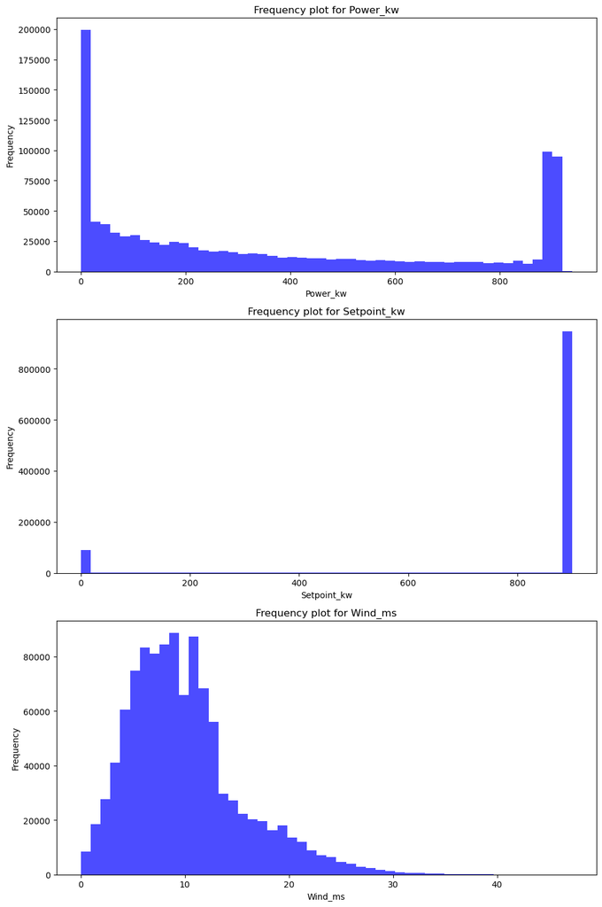

```python
def plot_histograms(dataframe):
    numeric_columns = dataframe.select_dtypes(include='number').columns
    num_columns = len(numeric_columns)
    fig, axes = plt.subplots(nrows=num_columns, ncols=1, figsize=(10, num_columns * 5))

    for i, column in enumerate(numeric_columns):
        ax = axes[i] if num_columns > 1 else axes
        dataframe[column].plot(kind='hist', bins=50, ax=ax, alpha=0.7, color='blue')
        ax.set_title(f'Frequency plot for {column}')
        ax.set_xlabel(column)
        ax.set_ylabel('Frequency')

    plt.tight_layout()
    plt.show()

# Call the function to plot histograms
plot_histograms(turbine_data)
```

For turbine telemetry dataset:

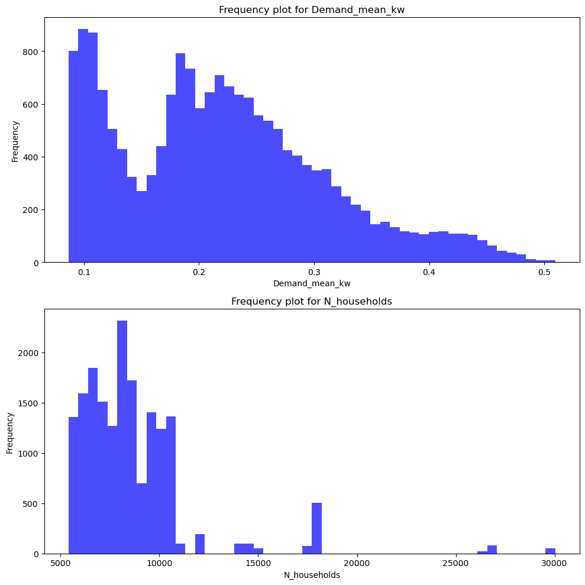

```python
# Call the function to plot histograms
plot_histograms(residential_demand)
```

For residential demand dataset:

## 3.1 Calculating Curtailment

#### Step 1: Understanding the relationship between wind speed and power.

Wind speed is crucial for wind turbine energy generation. Stronger winds cause the turbine blades to rotate faster, within design limits, resulting in more mechanical and electrical power. The turbine's power output typically increases cubically with wind speed. This relationship between wind speed (m/s) and power output (KW) is illustrated in the figure below.

The power output of a wind turbine is given by the formula: $$ P = 0.5 C_p \rho \pi R^2 V^3 $$

For our purposes, we will bundle up the unknown factors into 'K' to reduce the equation to the following:

$$ P = k V^3 $$

To calculate the K parameter, we will use the turbine_telemetry dataset.

Below is a scatterplot of the wind speed and the power generated by 1 turbine.

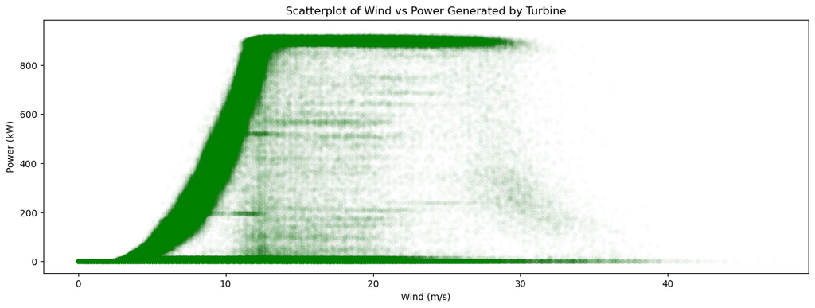

```python
turbine_data.plot.scatter('Wind_ms','Power_kw', alpha = 0.01, color='green', figsize=(15,5))
plt.xlabel('Wind (m/s)')
plt.ylabel('Power (kW)')
plt.title('Scatterplot of Wind vs Power Generated by Turbine')
```

We can see that that the Power generated seems to pick up @ 4m/s of wind speed and increases exponentially till about 12m/s. We will need to clean the data where power generated is 0 with significant wind speed (meaning the turbine was switched off)

```python
# Using the data where setpoint was maximum.
turbine_data_cleaned = turbine_data[turbine_data['Setpoint_kw'] == 900].copy()

# Using the data where wind speed for more than 5 and power generated was not 0
turbine_data_cleaned.loc[((turbine_data_cleaned.Wind_ms > 5) & (turbine_data_cleaned.Power_kw.abs() < 0.0000001))] = np.nan
turbine_data_cleaned.dropna(inplace=True)

# Checking if data is cleaned appropriately
turbine_data_cleaned.isna().sum()
```

```
Timestamp      0
Power_kw       0
Setpoint_kw    0
Wind_ms        0
dtype: int64
```

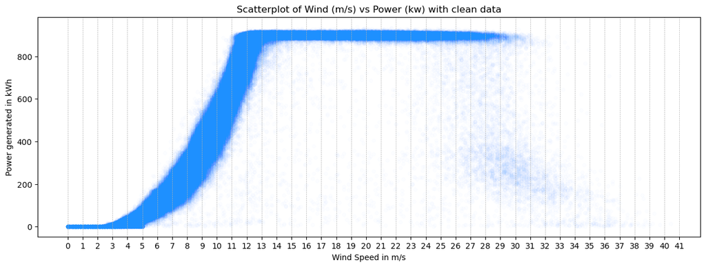

```python
turbine_data_cleaned.plot.scatter('Wind_ms', 'Power_kw', alpha=0.01, figsize=(15, 5), color ='dodgerblue')
plt.xlabel('Wind Speed in m/s')
plt.ylabel('Power generated in kWh')
plt.title('Scatterplot of Wind (m/s) vs Power (kw) with clean data')
plt.xticks(np.arange(0, turbine_data_cleaned['Wind_ms'].max() + 1, 1))
plt.grid(True, which='both', axis='x', linestyle='--', linewidth=0.5)
```

The provided code calculates and plots the power curve for wind turbines by analyzing the relationship between wind speed (in meters per second) and power output (in kilowatts). Initially, wind speed values are categorized into bins ranging from 0 to 17 m/s with a step size of 0.2 m/s. Each wind speed value is assigned to its corresponding bin using the bin_assigner function. The dataset is then grouped by these bins, and the median power output is calculated for each bin. The average wind speed for each bin is computed and added as a new column. Finally, a plot of wind speed versus median power output is generated, illustrating the power curve. This curve helps visualize how power generation increases with wind speed up to a certain point, beyond which the power output plateaus.

```python
bins_ = [round(i, 2) for i in np.arange(0, 17, .2)] # Generate a list of values from 0 to 17 with a step size of 0.2, rounded to two decimal places
bins = list(zip(bins_, bins_[1:])) # Pair consecutive values to form tuples representing intervals (bins)

def bin_assigner(x, bins=bins):
    for k, (a, b) in enumerate(bins): # Iterate through each interval (a, b) in bins
        if x >= a and x < b: # Check if x falls within the interval (a, b)
            return bins[k] # Return the corresponding bin
    else:
        return (17, np.inf) # If x does not fall within any interval, return (17, np.inf)

gp_ = turbine_data_cleaned.copy() # Create a copy of the DataFrame to avoid modifying the original

gp_['bins'] = gp_.Wind_ms.apply(bin_assigner) # Apply bin_assigner to each value in Wind_ms and create a new column 'bins' with the assigned bins

p_w = gp_[['Power_kw', 'bins']].groupby('bins') # Group the DataFrame by the 'bins' column
power_med = p_w.quantile(0.5) # Calculate the median (0.5 quantile) of the 'Power_kw' column for each bin group
```

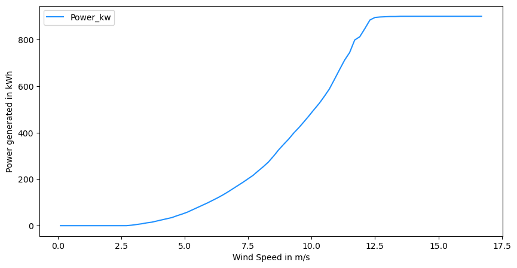

```python
wind_spd = [] # Initialize an empty list to store the average wind speed values

for i, idx in enumerate(power_med.index): # Iterate over the indices of power_med
    try:
        if isinstance(idx, tuple): # Check if the index is a tuple (MultiIndex)
            # If the index is a tuple, unpack it
            a, b = idx
            avg_idx = (float(a) + float(b)) / 2 # Calculate the average of the tuple values
        else:
            # If the index is a single value, use it directly
            avg_idx = float(idx)
        wind_spd.append(avg_idx) # Append the calculated average to the wind_spd list
    except ValueError:
        print(f"Error converting index value {idx} to float") # Print an error message if conversion fails

power_med['wind_ms'] = wind_spd # Add the wind_spd list as a new column 'wind_ms' in the power_med DataFrame
power_med.head(25) # Display the first 25 rows of the DataFrame

power_med.plot('wind_ms', 'Power_kw', figsize=(10, 5), color='dodgerblue') # Plot wind_ms vs. Power_kw with specified figure size and color
plt.xlabel('Wind Speed in m/s') # Set the label for the x-axis
plt.ylabel('Power generated in kWh') # Set the label for the y-axis
```

```python
# Calculating K parameter
# Making a new column for Wind^3
power_med['wind_ms^3'] = power_med.wind_ms**3

# Only extract the values where wind is higher than 5 m/s and smaller than 17 m/s
power_med_k = power_med[(power_med.wind_ms >= 4) & (power_med.wind_ms <= 12.4)]
power_med_k['k'] = power_med_k.Power_kw/power_med_k['wind_ms^3']
k_parameter = power_med_k.k.mean()
power_med_k[10:20]
```

| bins | Power_kw | wind_ms | wind_ms^3 | k |
| --- | --- | --- | --- | --- |
| (6.0, 6.2) | 109.0 | 6.1 | 226.981 | 0.480216 |
| (6.2, 6.4) | 120.0 | 6.3 | 250.047 | 0.479910 |
| (6.4, 6.6) | 132.0 | 6.5 | 274.625 | 0.480655 |
| (6.6, 6.8) | 145.0 | 6.7 | 300.763 | 0.482107 |
| (6.8, 7.0) | 159.0 | 6.9 | 328.509 | 0.484005 |
| (7.0, 7.2) | 173.0 | 7.1 | 357.911 | 0.483360 |
| (7.2, 7.4) | 187.0 | 7.3 | 389.017 | 0.480699 |
| (7.4, 7.6) | 202.0 | 7.5 | 421.875 | 0.478815 |
| (7.6, 7.8) | 217.0 | 7.7 | 456.533 | 0.475322 |
| (7.8, 8.0) | 236.0 | 7.9 | 493.039 | 0.478664 |

```python
print(f'The approximate value of the wind capacity is {round(k_parameter,3)}')
```

```
The approximate value of the wind capacity is 0.471
```

```python
# Calculating Potential kW
#Resampling turbine data to hourly
turbine_data_cleaned.set_index('Timestamp', inplace=True)
turbine_data_cleaned_rs = turbine_data_cleaned.resample('h').mean()

# Using the power curve to create a function that uses the wind speed
def calculate_potential_kw(row, k):
    if row['Wind_ms'] < 2.5:
        return 0
    elif 2.5 < row['Wind_ms'] < 12.5:
        return round(k * row['Wind_ms'] ** 3, 3)
    else:
        return 900

turbine_data_cleaned_rs['Potential_kw'] = turbine_data_cleaned_rs.apply(calculate_potential_kw, axis=1, k=k_parameter)

turbine_data_cleaned_rs.head()
df_turbine_final = turbine_data_cleaned_rs.loc[turbine_data_cleaned_rs.index.year == 2017]
df_turbine_final.head()
```

| Timestamp | Power_kw | Setpoint_kw | Wind_ms | Potential_kw |
| --- | --- | --- | --- | --- |
| 2017-01-01 00:00:00 | 896.150000 | 900.0 | 14.963333 | 900.0 |
| 2017-01-01 01:00:00 | 905.350000 | 900.0 | 16.731667 | 900.0 |
| 2017-01-01 02:00:00 | 906.170213 | 900.0 | 17.995745 | 900.0 |
| 2017-01-01 03:00:00 | 904.109589 | 900.0 | 17.183562 | 900.0 |
| 2017-01-01 04:00:00 | 904.316667 | 900.0 | 16.130000 | 900.0 |

The code is focused on analysing and visualising the relationship between wind speed and power generation for wind turbines. Initially, the dataset is filtered to include only the data points where the setpoint is at its maximum value of 900 kW. Further cleaning is performed by removing data points where the wind speed is above 5 m/s, but no power is generated, indicating potential anomalies. A scatter plot is then created to visualize the cleaned data, showing the relationship between wind speed and power output.

Next, wind speed values are categorized into bins, and the median power output is calculated for each bin, resulting in a power curve that illustrates how power generation varies with wind speed. This curve is essential for understanding turbine performance. The 'k' parameter, which is 0.471 is used to estimate potential power output based on wind speed, particularly for speeds between 4 and 12.4 m/s.

Finally, the data is resampled to an hourly frequency, and a function is applied to estimate the potential power output for each hour using the calculated 'k' parameter. The dataset is filtered to include only data from 2017, and the final cleaned dataset is prepared for further analysis.

### Step 2. Resampling & calculating demand from the residential_demand dataset

```python
residential_demand.head()
```

|  | Timestamp | Demand_mean_kw | N_households |
| --- | --- | --- | --- |
| 0 | 2017-01-01 00:00:00 | 0.220106 | 5428 |
| 1 | 2017-01-01 00:30:00 | 0.205945 | 5429 |
| 2 | 2017-01-01 01:00:00 | 0.189090 | 5429 |
| 3 | 2017-01-01 01:30:00 | 0.173118 | 5429 |
| 4 | 2017-01-01 02:00:00 | 0.159051 | 5429 |

```python
residential_demand['Demand_sample_kw']=residential_demand['Demand_mean_kw']*residential_demand['N_households']
# Demand_mean_total stores the demand for all households
residential_demand['Demand_total_kw'] = residential_demand['Demand_sample_kw']*10385/residential_demand['N_households']


residential_demand.set_index('Timestamp', inplace=True)
residential_demand_cleaned = residential_demand.resample('h').mean()
df_residential_demand_final = residential_demand_cleaned.loc[residential_demand_cleaned.index.year == 2017]
df_residential_demand_final.head()
```

| Timestamp | Demand_mean_kw | N_households | Demand_sample_kw | Demand_total_kw |
| --- | --- | --- | --- | --- |
| 2017-01-01 00:00:00 | 0.213026 | 5428.5 | 1156.407001 | 2212.272907 |
| 2017-01-01 01:00:00 | 0.181104 | 5429.0 | 983.213502 | 1880.764822 |
| 2017-01-01 02:00:00 | 0.153353 | 5429.0 | 832.555500 | 1592.574851 |
| 2017-01-01 03:00:00 | 0.133578 | 5429.0 | 725.196498 | 1387.210469 |
| 2017-01-01 04:00:00 | 0.122200 | 5429.0 | 663.425000 | 1269.049295 |

### Step 3. Calculating Exported energy + merging all data in one dataframe

```python
# Merging all datasets
merged_final = pd.merge(df_turbine_final, df_residential_demand_final, on='Timestamp', how='inner')

# Calculating actual generated power
merged_final['Generated_Total_kw']=500*merged_final['Power_kw']  #multiplying by 500 for the # of turbines
merged_final.head()
```

| Timestamp | Power_kw | Setpoint_kw | Wind_ms | Potential_kw | Demand_mean_kw | N_households | Demand_sample_kw | Demand_total_kw | Generated_Total_kw |
| --- | --- | --- | --- | --- | --- | --- | --- | --- | --- |
| 2017-01-01 00:00:00 | 896.150000 | 900.0 | 14.963333 | 900.0 | 0.213026 | 5428.5 | 1156.407001 | 2212.272907 | 448075.000000 |
| 2017-01-01 01:00:00 | 905.350000 | 900.0 | 16.731667 | 900.0 | 0.181104 | 5429.0 | 983.213502 | 1880.764822 | 452675.000000 |
| 2017-01-01 02:00:00 | 906.170213 | 900.0 | 17.995745 | 900.0 | 0.153353 | 5429.0 | 832.555500 | 1592.574851 | 453085.106383 |
| 2017-01-01 03:00:00 | 904.109589 | 900.0 | 17.183562 | 900.0 | 0.133578 | 5429.0 | 725.196498 | 1387.210469 | 452054.794521 |
| 2017-01-01 04:00:00 | 904.316667 | 900.0 | 16.130000 | 900.0 | 0.122200 | 5429.0 | 663.425000 | 1269.049295 | 452158.333333 |

```python
# Calculating export
merged_final['Export'] = merged_final.apply(lambda row: min(row['Generated_Total_kw'] - row['Demand_total_kw'], 40*10**3) if row['Generated_Total_kw'] > row['Demand_total_kw'] else 0, axis=1)
merged_final.head()
```

| Timestamp | Power_kw | Setpoint_kw | Wind_ms | Potential_kw | Demand_mean_kw | N_households | Demand_sample_kw | Demand_total_kw | Generated_Total_kw | Export |
| --- | --- | --- | --- | --- | --- | --- | --- | --- | --- | --- |
| 2017-01-01 00:00:00 | 896.150000 | 900.0 | 14.963333 | 900.0 | 0.213026 | 5428.5 | 1156.407001 | 2212.272907 | 448075.000000 | 40000.0 |
| 2017-01-01 01:00:00 | 905.350000 | 900.0 | 16.731667 | 900.0 | 0.181104 | 5429.0 | 983.213502 | 1880.764822 | 452675.000000 | 40000.0 |
| 2017-01-01 02:00:00 | 906.170213 | 900.0 | 17.995745 | 900.0 | 0.153353 | 5429.0 | 832.555500 | 1592.574851 | 453085.106383 | 40000.0 |
| 2017-01-01 03:00:00 | 904.109589 | 900.0 | 17.183562 | 900.0 | 0.133578 | 5429.0 | 725.196498 | 1387.210469 | 452054.794521 | 40000.0 |
| 2017-01-01 04:00:00 | 904.316667 | 900.0 | 16.130000 | 900.0 | 0.122200 | 5429.0 | 663.425000 | 1269.049295 | 452158.333333 | 40000.0 |

```python
# Calculating curtailment
merged_final['Curtailed_kw']=500*merged_final['Potential_kw']-merged_final['Demand_total_kw']-merged_final['Export']
merged_final['Curtailed_kw'] = np.maximum(merged_final['Curtailed_kw'], 0)
merged_final=merged_final.reset_index()
merged_final.head()
```

|  | Timestamp | Power_kw | Setpoint_kw | Wind_ms | Potential_kw | Demand_mean_kw | N_households | Demand_sample_kw | Demand_total_kw | Generated_Total_kw | Export | Curtailed_kw |
| --- | --- | --- | --- | --- | --- | --- | --- | --- | --- | --- | --- | --- |
| 0 | 2017-01-01 00:00:00 | 896.150000 | 900.0 | 14.963333 | 900.0 | 0.213026 | 5428.5 | 1156.407001 | 2212.272907 | 448075.000000 | 40000.0 | 407787.727093 |
| 1 | 2017-01-01 01:00:00 | 905.350000 | 900.0 | 16.731667 | 900.0 | 0.181104 | 5429.0 | 983.213502 | 1880.764822 | 452675.000000 | 40000.0 | 408119.235178 |
| 2 | 2017-01-01 02:00:00 | 906.170213 | 900.0 | 17.995745 | 900.0 | 0.153353 | 5429.0 | 832.555500 | 1592.574851 | 453085.106383 | 40000.0 | 408407.425149 |
| 3 | 2017-01-01 03:00:00 | 904.109589 | 900.0 | 17.183562 | 900.0 | 0.133578 | 5429.0 | 725.196498 | 1387.210469 | 452054.794521 | 40000.0 | 408612.789531 |
| 4 | 2017-01-01 04:00:00 | 904.316667 | 900.0 | 16.130000 | 900.0 | 0.122200 | 5429.0 | 663.425000 | 1269.049295 | 452158.333333 | 40000.0 | 408730.950705 |

```python
merged_final.set_index('Timestamp', inplace=True)
merged_final_YE = merged_final.resample('y').sum()
merged_final_YE.head()
```

| Timestamp | Power_kw | Setpoint_kw | Wind_ms | Potential_kw | Demand_mean_kw | N_households | Demand_sample_kw | Demand_total_kw | Generated_Total_kw | Export | Curtailed_kw |
| --- | --- | --- | --- | --- | --- | --- | --- | --- | --- | --- | --- |
| 2017-12-31 | 3.529244e+06 | 7110000.0 | 79791.008071 | 4300178.604 | 1918.039488 | 75554022.0 | 1.647036e+07 | 1.991884e+07 | 1.764622e+09 | 2.759851e+08 | 1.855183e+09 |

```python
curtailed_2017=merged_final['Curtailed_kw'].sum()/1000
print('Power Curtailment in 2017 = ',curtailed_2017.round(2),'MW')
```

```
Power Curtailment in 2017 =  1855182.57 MW
```

The code from step 2 focuses on processing the residential demand data, merging it with turbine data, and calculating energy export and curtailment for a comprehensive analysis.

Firstly, the code calculates the total residential demand in kilowatts (kW). It starts by computing the sample demand by multiplying the mean demand per household by the number of households. This sample demand is then scaled to the total number of households (10,385) to get the total demand in kW. The dataset is resampled to an hourly frequency, and data specific to the year 2017 is extracted.

Next, the cleaned residential demand data is merged with the turbine data based on the timestamp. This combined dataset allows for a comprehensive view of energy generation and demand. The total generated power is calculated by multiplying the power output of a single turbine by the number of turbines (500).

The code then calculates the amount of energy exported by comparing the generated power with the total demand. If the generated power exceeds the demand, the excess energy is either exported (up to a maximum of 40,000 kW) or curtailed. Curtailment is calculated as the difference between the potential power output, total demand, and the exported energy, ensuring that curtailment values are non-negative.

Finally, the total Power Curtailment in 2017 is calculated to be 1855182.57 MW.

## 3.2 Demand Response

Once all the curtailment has been calculated for the wind turbines, the next step is to calculate the curtailment reduction from the demand side of the households of Orkney. An explanatory data analysis will be conducted on the residential demand data to understand the patterns and trends in the energy consumption of the households. This will help in estimating the potential curtailment reduction from the demand side. The data will be preprocessed and explored to understand the distribution of demand, seasonal patterns, hourly patterns, and total energy consumed.

```python
import pandas as pd
import numpy as np
import matplotlib.pyplot as plt
import seaborn as sns
import datetime
```

```python
demand = pd.read_csv('Residential_demand.csv')
```

### Descriptive Analysis and Data Preprocessing

```python
demand.info()
```

```
<class 'pandas.core.frame.DataFrame'>
RangeIndex: 17568 entries, 0 to 17567
Data columns (total 3 columns):
 #   Column          Non-Null Count  Dtype
---  ------          --------------  -----
 0   Timestamp       17568 non-null  object
 1   Demand_mean_kw  17568 non-null  float64
 2   N_households    17568 non-null  int64
dtypes: float64(1), int64(1), object(1)
memory usage: 411.9+ KB
```

```python
# Check for missing values
missing_values = demand.isnull().sum()
# Display the results
print(missing_values)
```

```
Timestamp         0
Demand_mean_kw    0
N_households      0
dtype: int64
```

Upon analysing the values for the dataset, we find that there are no missing values in the dataset. This is a good sign as we can proceed with the analysis without having to worry about imputing missing values. Additionally, the dataset contains the columns *"Timestamp", "Demand_mean_kw" and "N_households"*:

- The "Timestamp" column contains the date and time of the demand data recorded at every 30 min intervals for 1 year from 1st January 2017 to 1 January 2018.
- The "Demand_mean_kw" column contains the average demand in kilowatts for each timestamp.
- The "N_households" column contains the number of households in Orkney at that timestamp.

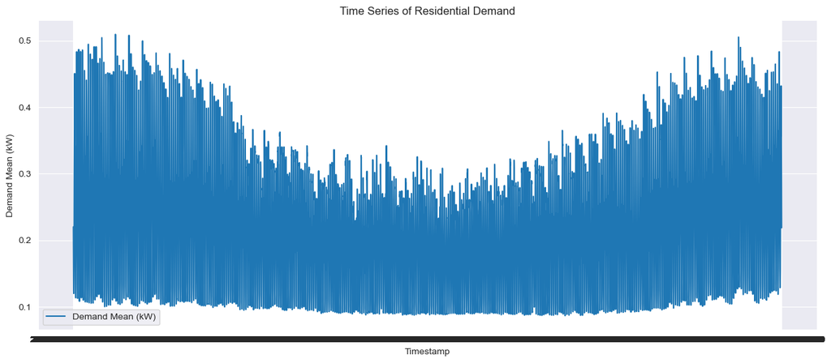

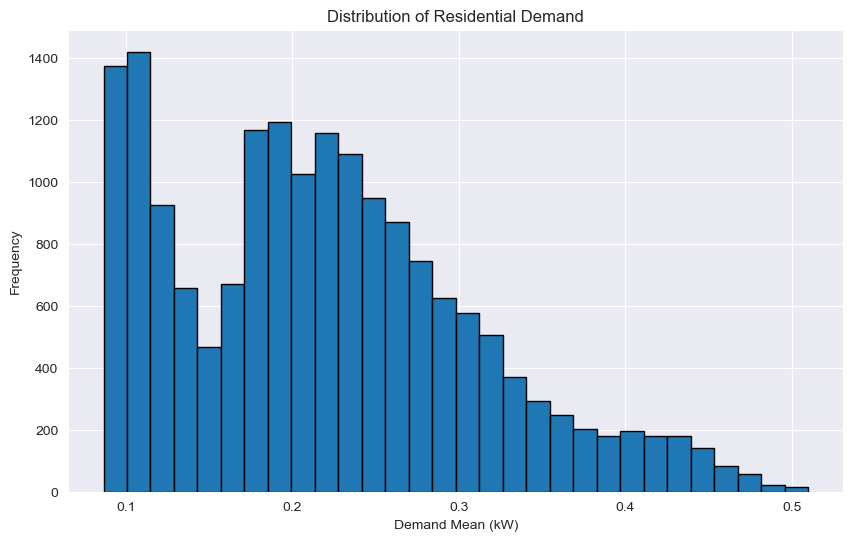

```
Total demand for the entire dataset period:  39971661.94027373 kWh
```

```python
# Plot the time series of demand
plt.figure(figsize=(15, 6))
plt.plot(demand['Timestamp'], demand['Demand_mean_kw'], label='Demand Mean (kW)')
plt.xlabel('Timestamp')
plt.ylabel('Demand Mean (kW)')
plt.title('Time Series of Residential Demand')
plt.legend()
plt.grid(True)
plt.show()

# Calculate the total demand for the entire dataset period
total_demand_entire_period = demand['Demand_mean_kw'].sum()
x = total_demand_entire_period *10385

# Plot the distribution of the demand
plt.figure(figsize=(10, 6))
plt.hist(demand['Demand_mean_kw'], bins=30, edgecolor='black')
plt.xlabel('Demand Mean (kW)')
plt.ylabel('Frequency')
plt.title('Distribution of Residential Demand')
plt.grid(True)
plt.show()

print("Total demand for the entire dataset period: ", x, "kWh")
```

### Analysis of the Distribution of Residential Demand

The purpose of analysing the distribution of residential demand is to understand the patterns and trends in household energy consumption. This information is crucial for estimating potential curtailment reductions from the demand side and designing effective energy management strategies.

The histogram of the residential demand mean (in kW) reveals that the distribution is right-skewed, with most demand values concentrated at the lower end of the scale. This indicates that lower demand levels are more common among households, while higher demand levels are less frequent. The peak of the histogram is around the lower demand mean values, representing the most frequent levels of household energy consumption.

Below is a graph for how the demand for households are throughout the different seasons throughout the year.

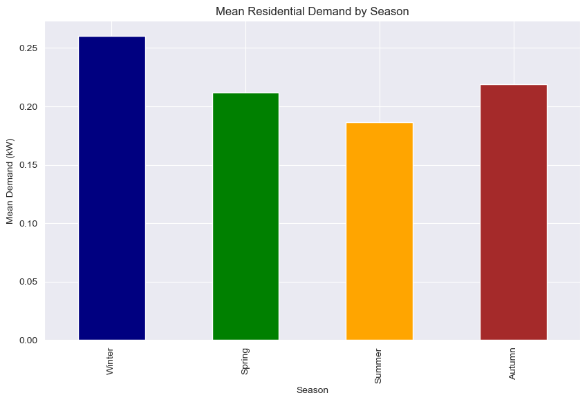

```
Season
Winter    0.260040
Spring    0.211540
Summer    0.186564
Autumn    0.218658
Name: Demand_mean_kw, dtype: float64
```

```python
import pandas as pd
import matplotlib.pyplot as plt

# Convert Timestamp to datetime
demand['Timestamp'] = pd.to_datetime(demand['Timestamp'])

# Define a function to determine the season based on the month
def get_season(month):
    if month in [12, 1, 2]:
        return 'Winter'
    elif month in [3, 4, 5]:
        return 'Spring'
    elif month in [6, 7, 8]:
        return 'Summer'
    else:
        return 'Autumn'

# Add a 'Month' column
demand['Month'] = demand['Timestamp'].dt.month

# Add a 'Season' column
demand['Season'] = demand['Month'].apply(get_season)

# Group the demand by season
seasonal_demand = demand.groupby('Season')['Demand_mean_kw'].mean().reindex(['Winter', 'Spring', 'Summer', 'Autumn'])

# Plot the seasonal demand
plt.figure(figsize=(10, 6))
seasonal_demand.plot(kind='bar', color=['navy', 'green', 'orange', 'brown'])
plt.xlabel('Season')
plt.ylabel('Mean Demand (kW)')
plt.title('Mean Residential Demand by Season')
plt.grid(True)
plt.show()

# Display the seasonal demand data
seasonal_demand
```

### Analysis of the Bar Chart: Mean Residential Demand by Season

The bar chart displays the mean residential demand (in kW) for each season: Winter, Spring, Summer, and Autumn. Winter exhibits the highest mean residential demand, approximately 0.26 kW, which is expected due to the increased use of heating systems to maintain comfortable indoor temperatures during the cold months. This significant demand highlights the importance of efficient heating solutions and the potential for demand-side management during peak periods.

Understanding these seasonal demand patterns is crucial for planning demand response strategies. Kaluza can anticipate higher energy consumption in winter and manage peak loads more effectively for the curtailed energy. By analysing the seasonal demand trends, we can tailor demand response initiatives to address specific challenges during different times of the year.

However, to further refine our demand response strategy, we need to explore the hourly patterns of the demand data. This will provide insights into the daily variations in energy consumption and help identify peak demand periods that require targeted interventions.

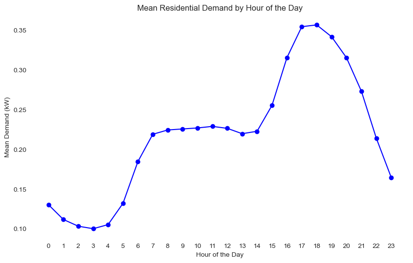

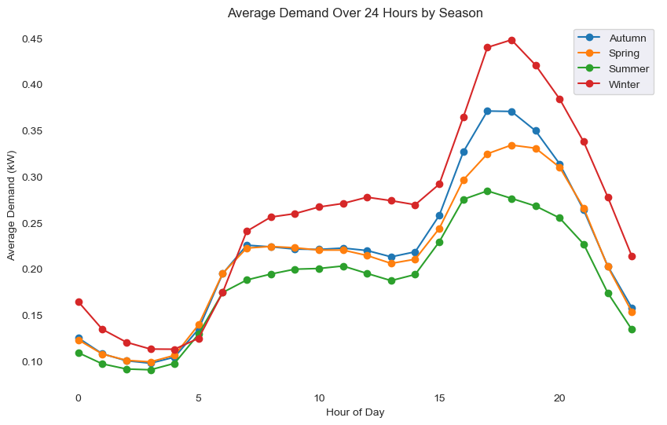

```python
import pandas as pd
import matplotlib.pyplot as plt

# Load the data
demand = pd.read_csv('Residential_demand.csv')

# Convert 'Timestamp' to datetime if it's not already
demand['Timestamp'] = pd.to_datetime(demand['Timestamp'])

# Extract the hour from the 'Timestamp'
demand['Hour'] = demand['Timestamp'].dt.hour

# Define a function to determine the season based on the month
def get_season(month):
    if month in [12, 1, 2]:
        return 'Winter'
    elif month in [3, 4, 5]:
        return 'Spring'
    elif month in [6, 7, 8]:
        return 'Summer'
    else:
        return 'Autumn'

# Add a 'Month' column
demand['Month'] = demand['Timestamp'].dt.month

# Add a 'Season' column
demand['Season'] = demand['Month'].apply(get_season)

# Group by 'Season' and 'Hour' and calculate the mean demand for each group
average_hourly_demand_by_season = demand.groupby(['Season', 'Hour'])['Demand_mean_kw'].mean().reset_index()

# Group by hour and calculate the mean demand for each hour
hourly_demand = demand.groupby('Hour')['Demand_mean_kw'].mean()

# Plot the hourly demand
fig, ax = plt.subplots(figsize=(10, 6))
ax.plot(hourly_demand.index, hourly_demand.values, marker='o', linestyle='-', color='b')
ax.set_xlabel('Hour of the Day')
ax.set_ylabel('Mean Demand (kW)')
ax.set_title('Mean Residential Demand by Hour of the Day')
plt.xticks(range(24))

# Set the background color to none
fig.patch.set_facecolor('none')
ax.set_facecolor('none')

ax.grid(True)
plt.show()

# Create a figure and axis for the plot
fig, ax = plt.subplots(figsize=(10, 6))

# Plot the average demand over time for each season
for season in average_hourly_demand_by_season['Season'].unique():
    season_data = average_hourly_demand_by_season[average_hourly_demand_by_season['Season'] == season]
    ax.plot(season_data['Hour'], season_data['Demand_mean_kw'], label=season, marker='o')

# Add title, labels, and legend to the plot
ax.set_title('Average Demand Over 24 Hours by Season')
ax.set_xlabel('Hour of Day')
ax.set_ylabel('Average Demand (kW)')
ax.legend()

# Set the background color to none
fig.patch.set_facecolor('none')
ax.set_facecolor('none')

ax.grid(True)
plt.show()
```

### Analysis of the Line Chart: Average Demand Over 24 Hours by Season

The line chart illustrates the average residential demand (in kW) over 24 hours for each season: Autumn, Spring, Summer, and Winter.

# 4. Results

## 4.1 Assumptions made for the model

Firstly, when calculating the curtailment reduction potential from the demand side, we need to make some assumptions and estimates based on the available data and information. These assumptions will help us determine the maximum curtailment reduction achievable through demand-side management strategies. The key assumptions for the model are as follows:

1. The maximum amount of energy that can be reduced from the total curtailment is limited by the total energy consumed by households in Orkney. This means that the curtailment reduction cannot exceed the total energy demand of the households
2. The capacity of the storage heaters determines the maximum amount of energy that can be stored and used for curtailment. The heater which we will be using is the [Quantum RF HHR Storage Heater] (https://www.dimplex.co.uk/en-gb/products/installed-heating/storage-heaters/quantum/quantum-rf-hhr-storage-heater#x-081407). The capacity of the heater is around 15.4 kWh with a charge time of 7.7 hours. This means that the heater can store up to 15.4 kWh of energy and can be charged once a day for a period of 7.7 hours.
3. The number of households in Orkney is 10385.
4. Technology hub that controls the heaters (so they can be retrofitted) can be assumed to be around the £100 mark per household. - Kaluzas device
5. The cost of a Quantum Heater in 2018 was around the £600 mark.
6. A single household in the UK on average has a [2-3 bedroom house] (https://www.globaldata.com/data-insights/macroeconomic/average-household-size-in-the-united-kingdom-2096133/#:~:text=the%20United%20Kingdom-,The%20United%20Kingdom%20had%20an%20average%20household%20size%20of%202.4,2010%2C%20between%202010%20and%202021), and the average household size is 2.4 people.
7. We also assume that each house will have atleast two quantum heaters to store the energy.
8. Another assumption made that each heater would be charged twice per day

Using these assumptions we can build a demand response model which will target the households in Orkney and estimate the curtailment reduction potential from the demand side.

#### Numerical assumptions made for the code below:

##### Constants:

- total_households = 10385
- heaters_per_household = 2
- heater_capacity_kwh = 15.4
- total_curtailed_energy_mwh = 1855182.57

##### Costs:

- cost_per_heater = 600 # in pounds
- discount_per_heater = 300 # in pounds
- installation_cost_per_heater = 100 # in pounds- Kalluza will incur a cost of £100 per heater for installation
- price_per_kwh_selling = 0.22 # selling price in pounds
- price_per_kwh_buying = 0.20 # buying price in pounds
- standing_charge_per_day = 0.40 # in pounds

##### Charge time in hours:

- charge_time_hours = 7.7

## 4.2 Heaters, energy consumption and heater costs

```python
# Define constants
total_households = 10385  # Total number of households
heaters_per_household = 2  # Number of heaters per household
heater_capacity_kwh = 15.4  # Heater capacity in kWh
total_curtailed_energy_mwh = 1855182.57  # Total curtailed energy in MWh

# Define costs
cost_per_heater = 300  # Cost per heater in pounds
installation_cost_per_heater = 100  # Installation cost per heater in pounds

# Define charge time in hours
charge_time_hours = 7.7  # Charge time for heaters in hours

# Calculate total heaters and their capacity
total_heaters = total_households * heaters_per_household  # Total number of heaters
total_heater_capacity_kwh = total_heaters * heater_capacity_kwh  # Total heater capacity in kWh

# Calculate annual energy consumption per household using electric heaters (kWh)
daily_energy_consumption_per_heater_kwh = heater_capacity_kwh *2  # Daily energy consumption per heater in kWh
annual_energy_consumption_per_household_kwh = daily_energy_consumption_per_heater_kwh * 365  # Annual energy consumption per household in kWh
total_annual_consumption_kwh = total_households * annual_energy_consumption_per_household_kwh  # Total annual energy consumption in kWh

# Convert annual consumption to MWh
total_annual_consumption_mwh = total_annual_consumption_kwh / 1000  # Total annual consumption in MWh

# Calculate costs
total_heater_cost = total_heaters * cost_per_heater  # Total cost of heaters in pounds
total_installation_cost = total_heaters * installation_cost_per_heater  # Total installation cost in pounds
total_cost = total_heater_cost + total_installation_cost  # Total cost in pounds

# Print results
print(f"Total number of heaters: {total_heaters}")
print(f"Total heater capacity (MWh): {total_heater_capacity_kwh / 1000:.2f}")
print(f"Total annual energy consumption for all households (MWh): {total_annual_consumption_mwh:.2f}")
print(f"Total curtailed energy (MWh): {total_curtailed_energy_mwh:.2f}")
print(f"Total heater cost incurred (£): {total_heater_cost}")
print(f"Total installation cost (£): {total_installation_cost}")
print(f"Total cost (£): {total_cost}")
```

```
Total number of heaters: 20770
Total heater capacity (MWh): 319.86
Total annual energy consumption for all households (MWh): 116748.17
Total curtailed energy (MWh): 1855182.57
Total heater cost incurred (£): 6231000
Total installation cost (£): 2077000
Total cost (£): 8308000
```

## 4.3 Demand response penetration rates

Below we calculate the impact of various levels of demand response penetration on energy consumption, curtailed energy reduction, and costs for electric heaters. Demand response penetration refers to the proportion of households participating in a demand response program, which in this case involves using electric heaters to absorb excess energy that would otherwise be curtailed. The code defines constants such as the total number of households (10,385), the number of heaters per household (2), heater capacity (15.4 kWh), and the total curtailed energy available (1,855,182.57 MWh). It also specifies the costs of heaters and their installation.

The code sets four penetration levels: 25%, 50%, 75%, and 100%. It computes the total annual energy consumption in megawatt-hours (MWh) for these households and determines how much this reduces the curtailed energy. Additionally, it calculates the total cost of purchasing, selling (at a discounted rate) and installing the heaters. The results, including penetration level, total heaters, annual consumption, reduced curtailed energy, and total cost, are displayed in a formatted table.

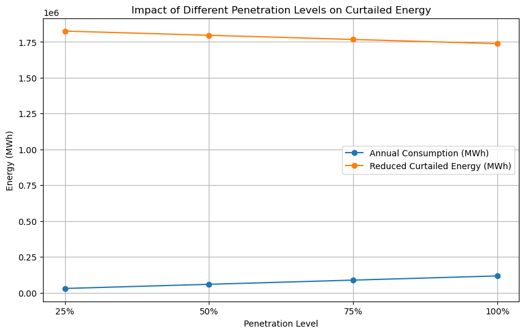

```
Insights:
Penetration Level: 25.0%
  Total Heaters: 5192
  Annual Consumption (MWh): 29184.23
  Reduced Curtailed Energy (MWh): 1825998.34
  Total Cost (£): 2076800
Penetration Level: 50.0%
  Total Heaters: 10384
  Annual Consumption (MWh): 58368.46
  Reduced Curtailed Energy (MWh): 1796814.11
  Total Cost (£): 4153600
Penetration Level: 75.0%
  Total Heaters: 15576
  Annual Consumption (MWh): 87552.70
  Reduced Curtailed Energy (MWh): 1767629.87
  Total Cost (£): 6230400
Penetration Level: 100.0%
  Total Heaters: 20770
  Annual Consumption (MWh): 116748.17
  Reduced Curtailed Energy (MWh): 1738434.40
  Total Cost (£): 8308000
```

```python
# Constants
total_households = 10385
heaters_per_household = 2
heater_capacity_kwh = 15.4
total_curtailed_energy_mwh = 1855182.57

# Costs
cost_per_heater = 300  # in pounds
installation_cost_per_heater = 100  # in pounds

# Charge time in hours
charge_time_hours = 7.7

# Penetration levels (percentages)
penetration_levels = [0.25, 0.50, 0.75, 1.00]
penetration_labels = ['25%', '50%', '75%', '100%']

# Lists to store results
total_heaters_list = []
annual_consumption_list = []
reduced_curtailed_energy_list = []
total_cost_list = []

# Calculations for each penetration level
for penetration in penetration_levels:
    # Number of households participating
    participating_households = int(total_households * penetration)

    # Total heaters and energy consumption
    total_heaters = participating_households * heaters_per_household
    total_heater_capacity_kwh = total_heaters * heater_capacity_kwh

    # Annual energy consumption per household using electric heaters (kWh)
    daily_energy_consumption_per_heater_kwh = heater_capacity_kwh * 2
    annual_energy_consumption_per_household_kwh = daily_energy_consumption_per_heater_kwh * 365
    total_annual_consumption_kwh = participating_households * annual_energy_consumption_per_household_kwh

    # Convert annual consumption to MWh
    total_annual_consumption_mwh = total_annual_consumption_kwh / 1000

    # Calculate reduced curtailed energy
    reduced_curtailed_energy_mwh = total_curtailed_energy_mwh - total_annual_consumption_mwh

    # Cost calculations
    total_heater_cost = total_heaters * cost_per_heater
    total_installation_cost = total_heaters * installation_cost_per_heater
    total_cost = total_heater_cost + total_installation_cost

    # Append results to lists
    total_heaters_list.append(total_heaters)
    annual_consumption_list.append(total_annual_consumption_mwh)
    reduced_curtailed_energy_list.append(reduced_curtailed_energy_mwh)
    total_cost_list.append(total_cost)

# Plotting the results
plt.figure(figsize=(10, 6))
plt.plot(penetration_labels, annual_consumption_list, label='Annual Consumption (MWh)', marker='o')
plt.plot(penetration_labels, reduced_curtailed_energy_list, label='Reduced Curtailed Energy (MWh)', marker='o')
plt.xlabel('Penetration Level')
plt.ylabel('Energy (MWh)')
plt.title('Impact of Different Penetration Levels on Curtailed Energy')
plt.legend()
plt.grid(True)
plt.show()

# Print insights
print("\nInsights:")
for i, penetration in enumerate(penetration_levels):
    print(f"Penetration Level: {penetration*100}%")
    print(f"  Total Heaters: {total_heaters_list[i]}")
    print(f"  Annual Consumption (MWh): {annual_consumption_list[i]:.2f}")
    print(f"  Reduced Curtailed Energy (MWh): {reduced_curtailed_energy_list[i]:.2f}")
    print(f"  Total Cost (£): {total_cost_list[i]}")
```

## 4.4 Financial strategy (breakeven point)

The new code below goes into the financial implications of different levels of demand response penetration by households using discounted electric heaters. It calculates key metrics at four penetration levels: 25%, 50%, 75%, and 100%. The primary objective, is to estimate annual revenue from selling energy and standing charges, and compute the net revenue after accounting for the cost of buying energy from the grid (which is also assumed based on recent numbers of selling price to consumers for energy https://www.uswitch.com/gas-electricity/guides/average-gas-and-electricity-bills-in-the-uk/). The breakeven period is calculated by dividing the total initial cost by the annual net revenue. These results, including total heaters, annual consumption, reduced curtailed energy, total cost, annual revenue, net revenue, and breakeven period, are displayed in a formatted table. Finally, a plot of the breakeven analysis illustrates how the time to recover the initial investment varies with different penetration levels, highlighting the economies of scale.

```
Penetration Level   Total Heaters  Annual Consumption (MWh) Reduced Curtailed Energy (MWh)Total Cost (£) Annual Revenue (£)  Net Revenue (£)     Breakeven (years)
25                  5192           29184.23                 1825998.34                    2076800        6799547.04          379016.00           5.48
50                  10384          58368.46                 1796814.11                    4153600        13599094.08         1536278.19          2.70
75                  15576          87552.70                 1767629.87                    6230400        20398641.12         3471786.56          1.79
100                 20770          116748.17                1738434.40                    8308000        27200807.40         6186136.80          1.34
```

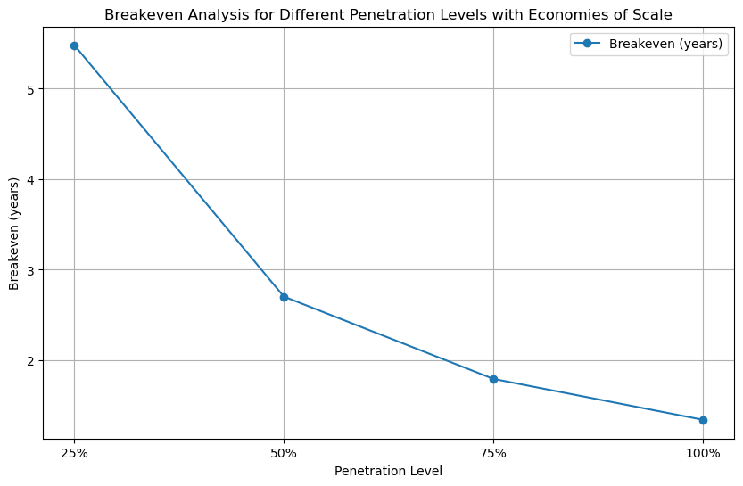

```python
# Costs
cost_per_heater = 600  # in pounds
discount_per_heater = 300  # in pounds
installation_cost_per_heater = 100  # in pounds
price_per_kwh_selling = 0.22  # selling price in pounds
standing_charge_per_day = 0.40  # in pounds

# Charge time in hours
charge_time_hours = 7.7

# Energy cost at different penetration levels
initial_price_per_kwh_buying = 0.22
final_price_per_kwh_buying = 0.18

# Penetration levels (percentages)
penetration_levels = [0.25, 0.50, 0.75, 1.00]
penetration_labels = ['25%', '50%', '75%', '100%']

# Lists to store results
total_heaters_list = []
annual_consumption_list = []
reduced_curtailed_energy_list = []
total_cost_list = []
annual_revenue_list = []
annual_net_revenue_list = []
breakeven_list = []

# Calculations for each penetration level
for penetration in penetration_levels:
    # Number of households participating
    participating_households = int(total_households * penetration)

    # Total heaters and energy consumption
    total_heaters = participating_households * heaters_per_household
    total_heater_capacity_kwh = total_heaters * heater_capacity_kwh

    # Annual energy consumption per household using electric heaters (kWh)
    daily_energy_consumption_per_heater_kwh = heater_capacity_kwh * 2
    annual_energy_consumption_per_household_kwh = daily_energy_consumption_per_heater_kwh * 365
    total_annual_consumption_kwh = participating_households * annual_energy_consumption_per_household_kwh

    # Convert annual consumption to MWh
    total_annual_consumption_mwh = total_annual_consumption_kwh / 1000

    # Calculate reduced curtailed energy
    reduced_curtailed_energy_mwh = total_curtailed_energy_mwh - total_annual_consumption_mwh

    # Cost calculations
    total_heater_cost = total_heaters * (cost_per_heater - discount_per_heater)
    total_installation_cost = total_heaters * installation_cost_per_heater
    total_cost = total_heater_cost + total_installation_cost

    # Linear interpolation for buying price
    price_per_kwh_buying = np.interp(penetration, [0.25, 1.0], [initial_price_per_kwh_buying, final_price_per_kwh_buying])

    # Revenue calculations
    annual_revenue_from_energy = total_annual_consumption_kwh * price_per_kwh_selling
    annual_standing_charge_revenue = participating_households * standing_charge_per_day * 365
    total_annual_revenue = annual_revenue_from_energy + annual_standing_charge_revenue

    # Net revenue calculation (considering the cost of buying energy from the grid)
    annual_cost_of_energy = total_annual_consumption_kwh * price_per_kwh_buying
    annual_net_revenue = total_annual_revenue - annual_cost_of_energy

    # Breakeven calculation (years)
    breakeven_years = total_cost / annual_net_revenue

    # Append results to lists
    total_heaters_list.append(total_heaters)
    annual_consumption_list.append(total_annual_consumption_mwh)
    reduced_curtailed_energy_list.append(reduced_curtailed_energy_mwh)
    total_cost_list.append(total_cost)
    annual_revenue_list.append(total_annual_revenue)
    annual_net_revenue_list.append(annual_net_revenue)
    breakeven_list.append(breakeven_years)

# Print results
print(f"{'Penetration Level':<20}{'Total Heaters':<15}{'Annual Consumption (MWh)':<25}{'Reduced Curtailed Energy (MWh)':<30}{'Total Cost (£)':<15}{'Annual Revenue (£)':<20}{'Net Revenue (£)':<20}{'Breakeven (years)':<20}")

for i, penetration in enumerate(penetration_levels):
    print(f"{penetration*100:<20.0f}{total_heaters_list[i]:<15}{annual_consumption_list[i]:<25.2f}{reduced_curtailed_energy_list[i]:<30.2f}{total_cost_list[i]:<15}{annual_revenue_list[i]:<20.2f}{annual_net_revenue_list[i]:<20.2f}{breakeven_list[i]:<20.2f}")

# Plotting the breakeven analysis
plt.figure(figsize=(10, 6))
plt.plot(penetration_labels, breakeven_list, label='Breakeven (years)', marker='o')
plt.xlabel('Penetration Level')
plt.ylabel('Breakeven (years)')
plt.title('Breakeven Analysis for Different Penetration Levels with Economies of Scale')
plt.legend()
plt.grid(True)
plt.show()
```

## 4.5 Return on investment

```
Penetration Level   ROI (5 years) (%)
25                  82.50
50                  106.83
75                  131.17
100                 155.50
```

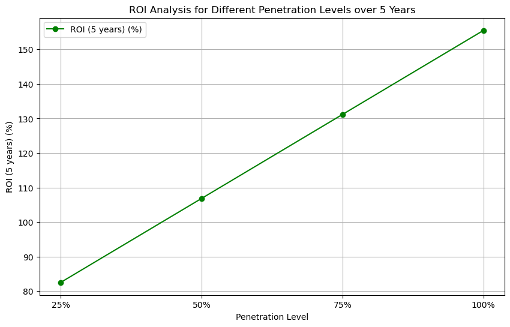

```python
# Costs
cost_per_heater = 600  # in pounds
discount_per_heater = 300  # in pounds
installation_cost_per_heater = 100  # in pounds
price_per_kwh_selling = 0.22  # selling price in pounds
standing_charge_per_day = 0.40  # in pounds

# Charge time in hours
charge_time_hours = 7.7

# Energy cost at different penetration levels
initial_price_per_kwh_buying = 0.22
final_price_per_kwh_buying = 0.18

# Penetration levels (percentages)
penetration_levels = [0.25, 0.50, 0.75, 1.00]
penetration_labels = ['25%', '50%', '75%', '100%']

# Lists to store results
roi_5_years_list = []

# Define your specific parameters
total_households = 10000  # Adjust as needed
heaters_per_household = 1  # Adjust as needed
heater_capacity_kwh = 2  # Adjust as needed
total_curtailed_energy_mwh = 100000  # Adjust as needed

# Calculations for each penetration level
for penetration in penetration_levels:
    # Number of households participating
    participating_households = int(total_households * penetration)

    # Total heaters and energy consumption
    total_heaters = participating_households * heaters_per_household
    total_heater_capacity_kwh = total_heaters * heater_capacity_kwh

    # Annual energy consumption per household using electric heaters (kWh)
    daily_energy_consumption_per_heater_kwh = heater_capacity_kwh * 2
    annual_energy_consumption_per_household_kwh = daily_energy_consumption_per_heater_kwh * 365
    total_annual_consumption_kwh = participating_households * annual_energy_consumption_per_household_kwh

    # Convert annual consumption to MWh
    total_annual_consumption_mwh = total_annual_consumption_kwh / 1000

    # Calculate reduced curtailed energy
    reduced_curtailed_energy_mwh = total_curtailed_energy_mwh - total_annual_consumption_mwh

    # Cost calculations
    total_heater_cost = total_heaters * (cost_per_heater - discount_per_heater)
    total_installation_cost = total_heaters * installation_cost_per_heater
    total_cost = total_heater_cost + total_installation_cost

    # Linear interpolation for buying price
    price_per_kwh_buying = np.interp(penetration, [0.25, 1.0], [initial_price_per_kwh_buying, final_price_per_kwh_buying])

    # Revenue calculations
    annual_revenue_from_energy = total_annual_consumption_kwh * price_per_kwh_selling
    annual_standing_charge_revenue = participating_households * standing_charge_per_day * 365
    total_annual_revenue = annual_revenue_from_energy + annual_standing_charge_revenue

    # Net revenue calculation (considering the cost of buying energy from the grid)
    annual_cost_of_energy = total_annual_consumption_kwh * price_per_kwh_buying
    annual_net_revenue = total_annual_revenue - annual_cost_of_energy

    # ROI calculation for the next 5 years
    cumulative_net_revenue_5_years = annual_net_revenue * 5
    roi_5_years = ((cumulative_net_revenue_5_years - total_cost) / total_cost) * 100

    # Append results to list
    roi_5_years_list.append(roi_5_years)

# Print results
print(f"{'Penetration Level':<20}{'ROI (5 years) (%)':<20}")

for i, penetration in enumerate(penetration_levels):
    print(f"{penetration*100:<20.0f}{roi_5_years_list[i]:<20.2f}")

# Plotting the ROI analysis
plt.figure(figsize=(10, 6))
plt.plot(penetration_labels, roi_5_years_list, label='ROI (5 years) (%)', marker='o', color='green')
plt.xlabel('Penetration Level')
plt.ylabel('ROI (5 years) (%)')
plt.title('ROI Analysis for Different Penetration Levels over 5 Years')
plt.legend()
plt.grid(True)
plt.show()
```

## 4.6 Reduction in curtailment at different levels

Next we calculate and visualize the reduction in curtailed energy at different levels of household participation. For each penetration level, the code calculates the number of participating households and the total number of heaters. It then computes the annual energy consumption per household. By subtracting this annual consumption from the total curtailed energy, the code determines the reduced curtailed energy for each penetration level. These reduced curtailment values are stored and then plotted. The resulting graph shows that as penetration levels increase, the curtailment of energy decreases, indicating that higher participation leads to more efficient energy use and less waste. This helps us to understand the impact of increased penetration on reducing energy curtailment.

```
Penetration Level | Reduced Curtailment (MWh) | Curtailment Reduction (%)
25.0              | 1825998.338               | 1.57
50.0              | 1796814.1060000001        | 3.15
75.0              | 1767629.874               | 4.72
100.0             | 1738434.4000000001        | 6.29
```

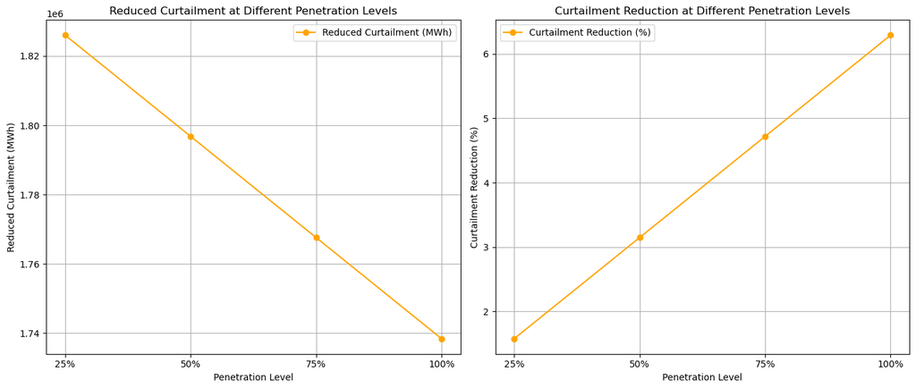

```python
# Constants
total_households = 10385
heaters_per_household = 2
heater_capacity_kwh = 15.4
total_curtailed_energy_mwh = 1855182.57

# Lists to store results
reduced_curtailed_energy_list = []
percentage_reduction_curtailment_list = []

# Calculations for each penetration level
for penetration in penetration_levels:
    # Number of households participating
    participating_households = int(total_households * penetration)

    # Total heaters and energy consumption
    total_heaters = participating_households * heaters_per_household

    # Annual energy consumption per household using electric heaters (kWh)
    daily_energy_consumption_per_heater_kwh = heater_capacity_kwh * 2
    annual_energy_consumption_per_household_kwh = daily_energy_consumption_per_heater_kwh * 365
    total_annual_consumption_kwh = participating_households * annual_energy_consumption_per_household_kwh

    # Convert annual consumption to MWh
    total_annual_consumption_mwh = total_annual_consumption_kwh / 1000

    # Calculate reduced curtailed energy
    reduced_curtailed_energy_mwh = total_curtailed_energy_mwh - total_annual_consumption_mwh

    # Calculate percentage reduction in curtailment
    percentage_reduction_curtailment = (total_annual_consumption_mwh / total_curtailed_energy_mwh) * 100

    # Append results to lists
    reduced_curtailed_energy_list.append(reduced_curtailed_energy_mwh)
    percentage_reduction_curtailment_list.append(percentage_reduction_curtailment)

# Print the numbers
print("Penetration Level | Reduced Curtailment (MWh) | Curtailment Reduction (%)")
for i, penetration in enumerate(penetration_levels):
    print(f"{penetration*100:<17} | {reduced_curtailed_energy_list[i]:<25} | {percentage_reduction_curtailment_list[i]:.2f}")

# Plotting the reduced curtailment and curtailment reduction graphs side by side
fig, (ax1, ax2) = plt.subplots(1, 2, figsize=(14, 6))

# Reduced curtailment graph
ax1.plot(penetration_labels, reduced_curtailed_energy_list, label='Reduced Curtailment (MWh)', marker='o', color='orange')
ax1.set_xlabel('Penetration Level')
ax1.set_ylabel('Reduced Curtailment (MWh)')
ax1.set_title('Reduced Curtailment at Different Penetration Levels')
ax1.legend()
ax1.grid(True)

# Curtailment reduction graph
ax2.plot(penetration_labels, percentage_reduction_curtailment_list, label='Curtailment Reduction (%)', marker='o', color='orange')
ax2.set_xlabel('Penetration Level')
ax2.set_ylabel('Curtailment Reduction (%)')
ax2.set_title('Curtailment Reduction at Different Penetration Levels')
ax2.legend()
ax2.grid(True)

# Display the plots
plt.tight_layout()
plt.show()
```

# 5. Discussion

## 5.1 Summary of results

Integrating quantum heaters at different penetration levels provides insightful results on energy curtailment reduction, costs, revenues, breakeven points, and return on investment (ROI). As penetration increases from 25% to 100%, the number of quantum heaters rises, leading to higher annual energy consumption and reduced curtailment. At 25% penetration, the reduced curtailment is approximately 1,825,998 MWh, accounting for a 1.57% reduction. This improves to about 1,738,434 MWh (6.29% reduction) at 100% penetration.

## 5.2 Future roadmap

Plan for the future is listed below:

These steps outline a strategic approach to progressively increase adoption rates, reduce energy curtailment, achieve financial sustainability, and maximize returns on investment, while also expanding local business partnerships and community engagement.

## 5.3 Limitations

1. **Assumptions**: The analysis is based on several assumptions, including energy consumption patterns, pricing models, and market behaviors, which may not fully represent real-world complexities.
2. **Economic and Political Conflicts**: Potential economic or political conflicts that could impact the implementation of the demand response program have not been considered. Changes in regulations, policies, or economic conditions could affect the feasibility and profitability of the program.
3. **Other Energy Sources**: The analysis does not account for other types of energy sources that could influence energy supply and demand dynamics in the region.
4. **Limited Information on Wind Turbines**: Detailed and concrete information about the wind turbines, such as maintenance costs, reliability, and operational efficiency, is not available. This information could impact the overall energy supply and curtailment calculations.

These limitations indicate the need for further detailed analysis and consideration of additional factors to more accurately assess the feasibility and impact of the demand response program. Addressing these limitations would provide a more comprehensive understanding of the program's potential and risks.

# 6. Conclusion

Leveraging Kaluza's Demand Response (DR) technology embedded within the Quantum heater system, underlines Kaluza's commitment to advancing sustainable energy solutions through cutting-edge technology. By orchestrating a cloud-based platform that manages devices in real-time, Kaluza enables precise control over energy consumption, supporting grid stability and reducing carbon emissions.

The integration of Kaluza's DR technology into the Quantum heater system not only optimizes energy usage but also provides consumers with cost-effective heating solutions. This project exemplifies how smart devices can be integrated into the energy grid to enhance efficiency and promote sustainable practices.

By implementing the Heat Smart Orkney project, Kaluza not only enhances energy efficiency but also offers cost-effective heating solutions to consumers.